# Outliers treatment - Matan Shemesh

#### יבוא הקובץ והספריות וחלוקה למשתנים נומריים וקטגוריאליים

```python
import pandas as pd
import numpy as np
import matplotlib.pyplot as plt
from matplotlib import rcParams
from matplotlib.backends.backend_pdf import PdfPages
import seaborn as sns
from scipy import stats
from scipy.stats import spearmanr
from scipy.stats import mannwhitneyu
import matplotlib.pyplot as plt
from scipy.stats import norm

df = pd.read_csv("D:/מבוא למדעי הנתונים/מטלה 1/death_prediction_synthetic.csv")

df.drop(['residence_cd', 'smoking', 'cancer'], axis = 1, inplace=True)

num_vars = ['age','weigh','heigh','BMI','bp_sys','bp_dias','HbA1c','glucose','creatinin','albumin','alb24h','ACR','cholesterol_total','LDL','HDL','triglycerides','TSH','gravity_u','WBC','RBC','platelets','MCV','MPV','framingham_cvd']
cat_vars = [col for col in df.columns if col not in num_vars]

num_vars_len = len(num_vars)
cat_vars_len = len(cat_vars)

#change the categorical variables to categoy type
for column in df[cat_vars]:
    df[column] = df[column].astype('category')
```

#### יצירת מטריצת ערכי קיצון (0/1)

```python
def create_outlier_mat(df):
    mat = np.zeros(df.shape)

    for col_idx, col in enumerate(df.columns):
        if col in num_vars:
            s = df[col]
            q1 = s.quantile(0.25)
            q3 = s.quantile(0.75)
            iqr = q3-q1
            lower = q1 - 1.5*iqr
            upper = q3 + 1.5*iqr

            outliers = s[(s<=lower) | (s>=upper)]

            for row_idx in outliers.index:
                mat[row_idx, col_idx] = 1

    return mat

outlier_mat = create_outlier_mat(df)
```

```python
outlier_mat.shape
```

```
(12438, 42)
```

#### .בדיקת קורלציות בין כל משתנה למשתנה המטרה: אם הקורלציה מובהקת, ובלי הערכי קיצון הקורלציה לא מובהקת - מוחקים

```python
p_value_corr = pd.DataFrame(columns = ['column', 'p-value correlation with outliers', 'p-value correlation without outliers', 'p-value correlation changed'])

for j, col in enumerate(df.columns):
    if col in num_vars:
        s = df[col]
        s_without_outliers = s.filter(items = [i for i in range(df.shape[0]) if outlier_mat[i,j] == 0])
        dead_5y_without_outliers = df['dead_5y'].filter(items = [i for i in range(df.shape[0]) if outlier_mat[i,j] == 0])
        corr1, p1 = stats.spearmanr(s, df['dead_5y'], nan_policy='omit')
        corr2, p2 = stats.spearmanr(s_without_outliers, dead_5y_without_outliers, nan_policy='omit')
        p_value_corr = p_value_corr.append({'column': col, 'p-value correlation with outliers': p1, 'p-value correlation without outliers': p2, 'p-value correlation changed': 'yes' if p1 < 0.05 and p2 >=0.05 else 'no'}, ignore_index=True)
p_value_corr
```

[output not shown]

[output cut: 27 more lines]

|  | column | p-value correlation with outliers | p-value correlation without outliers | p-value correlation changed |
| --- | --- | --- | --- | --- |
| 0 | age | 0.032390 | 0.034628 | no |
| 1 | weigh | 0.640407 | 0.253985 | no |
| 2 | heigh | 0.433266 | 0.361718 | no |
| 3 | BMI | 0.872282 | 0.337989 | no |
| 4 | bp_sys | 0.000053 | 0.588328 | yes |
| 5 | bp_dias | 0.286853 | 0.652097 | no |
| 6 | HbA1c | 0.348369 | 0.725857 | no |
| 7 | glucose | 0.789563 | 0.115565 | no |
| 8 | creatinin | 0.021887 | 0.999171 | yes |
| 9 | albumin | 0.002073 | 0.002039 | no |
| 10 | alb24h | 0.072376 | 0.948451 | no |
| 11 | ACR | 0.011973 | 0.284371 | yes |
| 12 | cholesterol_total | 0.000599 | 0.002247 | no |
| 13 | LDL | 0.003156 | 0.012636 | no |
| 14 | HDL | 0.338745 | 0.604795 | no |
| 15 | triglycerides | 0.217864 | 0.321922 | no |
| 16 | TSH | 0.002544 | 0.065652 | yes |
| 17 | gravity_u | 0.614453 | 0.650676 | no |
| 18 | WBC | 0.014828 | 0.175664 | yes |
| 19 | RBC | 0.375678 | 0.404761 | no |
| 20 | platelets | 0.566638 | 0.214264 | no |
| 21 | MCV | 0.062576 | 0.063367 | no |
| 22 | MPV | 0.026056 | 0.136441 | yes |
| 23 | framingham_cvd | 0.000037 | 0.003033 | no |

```python
# we will delete the outliers (replacing them with NaN)

outliers_to_drop = p_value_corr[p_value_corr['p-value correlation changed'] == 'yes'].column.values
corr_not_changed = p_value_corr[p_value_corr['p-value correlation changed'] == 'no'].column.values

for j, col in enumerate(df.columns):
    if col in outliers_to_drop:
        outlier_rows = [i for i in range(df.shape[0]) if outlier_mat[i,j] == 1 ]
        df.loc[outlier_rows,col] = np.nan
```

#### לכל המשתנים האלו הקורציה מול משתנה המטרה הפכה ללא מובהקת לאחר מחיקת הערכי קיצון

#### COCOR :

#### פונקציה שבודקת אם יש שוני מובהק בין שתי קורלציות

```python
def cocor(x1,y1, x2,y2):
    xy1 = x1.corr(y1, method='spearman')
    xy2 = x2.corr(y2, method='spearman')
    n1 = len(x1)
    n2 = len(x2)
    xy_z = 0.5 * np.log((1 + xy1)/(1 - xy1))
    ab_z = 0.5 * np.log((1 + xy2)/(1 - xy2))
    if n2 is None:
        n2 = n1
    se_diff_r = np.sqrt(1/(n1 - 3) + 1/(n2 - 3))
    diff = xy_z - ab_z
    z = abs(diff / se_diff_r)
    p = (1 - norm.cdf(z)) * 2
    return z, p
```

#### אם בלי הערכי קיצון הקורלציה עדיין נשארת מובהקת, בודקים האם השוני מובהק בין הקורלציות

```python
#correlation test - COCOR

outlier_treatments = pd.DataFrame(columns = ['column', 'p value correlation', 'correlation changed'])
for j, col in enumerate(df.columns):
    if col in num_vars and col in corr_not_changed:
        s = df[col]
        s_withot_outliers = s.filter(items = [i for i in range(df.shape[0]) if outlier_mat[i,j] == 0])
        _,p = cocor(s , df.dead_5y , s_withot_outliers , df.dead_5y)
        outlier_treatments = outlier_treatments.append({'column': col, 'p value correlation': p, 'correlation changed': 'yes' if p < 0.05 else 'no'}, ignore_index=True)

outlier_treatments
```

[output not shown]

[output cut: 12 more lines]

|  | column | p value correlation | correlation changed |
| --- | --- | --- | --- |
| 0 | age | 0.989041 | no |
| 1 | weigh | 0.629693 | no |
| 2 | heigh | 0.927152 | no |
| 3 | BMI | 0.570122 | no |
| 4 | bp_dias | 0.285903 | no |
| 5 | HbA1c | 0.685031 | no |
| 6 | glucose | 0.344946 | no |
| 7 | albumin | 0.982406 | no |
| 8 | alb24h | 0.023130 | yes |
| 9 | cholesterol_total | 0.805200 | no |
| 10 | LDL | 0.756011 | no |
| 11 | HDL | 0.761038 | no |
| 12 | triglycerides | 0.881099 | no |
| 13 | gravity_u | 0.969225 | no |
| 14 | RBC | 0.974023 | no |
| 15 | platelets | 0.630908 | no |
| 16 | MCV | 0.978633 | no |
| 17 | framingham_cvd | 0.449180 | no |

##### קיבלנו דאטה פריים שיש בה עמודה שאומרת האם השוני בין הקורלציה מובהק או לא

#### Kolmogorov - Smirnov test

#### בודקים האם יש שוני מובהק בהתפלגות לאחר מחיקת ערכי הקיצון

```python
p_values_dist = []

for j, col in enumerate(df.columns):
    if col in num_vars and col in corr_not_changed:
        s = df[col]
        s_withot_outliers = s.filter(items = [i for i in range(df.shape[0]) if outlier_mat[i,j] == 0])
        _,p = stats.kstest(s,s_withot_outliers)
        p_values_dist.append(p)

outlier_treatments['p-value dist'] = p_values_dist
outlier_treatments['distribution changed'] = ['yes' if p < 0.05 else 'no' for p in p_values_dist]
outlier_treatments
```

|  | column | p value correlation | correlation changed | p-value dist | distribution changed |
| --- | --- | --- | --- | --- | --- |
| 0 | age | 0.989041 | no | 9.200510e-01 | no |
| 1 | weigh | 0.629693 | no | 1.162745e-02 | yes |
| 2 | heigh | 0.927152 | no | 1.000000e+00 | no |
| 3 | BMI | 0.570122 | no | 1.260399e-02 | yes |
| 4 | bp_dias | 0.285903 | no | 7.150676e-07 | yes |
| 5 | HbA1c | 0.685031 | no | 2.685559e-09 | yes |
| 6 | glucose | 0.344946 | no | 5.438866e-20 | yes |
| 7 | albumin | 0.982406 | no | 8.069328e-01 | no |
| 8 | alb24h | 0.023130 | yes | 1.375169e-05 | yes |
| 9 | cholesterol_total | 0.805200 | no | 6.715558e-02 | no |
| 10 | LDL | 0.756011 | no | 1.917426e-01 | no |
| 11 | HDL | 0.761038 | no | 2.712349e-03 | yes |
| 12 | triglycerides | 0.881099 | no | 4.120518e-15 | yes |
| 13 | gravity_u | 0.969225 | no | 9.820608e-01 | no |
| 14 | RBC | 0.974023 | no | 3.684893e-01 | no |
| 15 | platelets | 0.630908 | no | 5.509925e-03 | yes |
| 16 | MCV | 0.978633 | no | 1.256170e-08 | yes |
| 17 | framingham_cvd | 0.449180 | no | 4.976801e-13 | yes |

#### רק אם השוני בין הקורלציות מובהק וגם יש שוני מובהק בהתפלגות - לא מוחקים את הערכי קיצון, כל השאר אפשר למחוק (להפוך לריק)

```python
# creating the decision column

def drop(df):
    if ((df['correlation changed'] == 'yes') & (df['distribution changed'] == 'yes')):
        return 'no'
    else:
        return 'yes'

outlier_treatments['drop'] = outlier_treatments.apply(drop, axis = 1)
outlier_treatments
```

|  | column | p value correlation | correlation changed | p-value dist | distribution changed | drop |
| --- | --- | --- | --- | --- | --- | --- |
| 0 | age | 0.989041 | no | 9.200510e-01 | no | yes |
| 1 | weigh | 0.629693 | no | 1.162745e-02 | yes | yes |
| 2 | heigh | 0.927152 | no | 1.000000e+00 | no | yes |
| 3 | BMI | 0.570122 | no | 1.260399e-02 | yes | yes |
| 4 | bp_dias | 0.285903 | no | 7.150676e-07 | yes | yes |
| 5 | HbA1c | 0.685031 | no | 2.685559e-09 | yes | yes |
| 6 | glucose | 0.344946 | no | 5.438866e-20 | yes | yes |
| 7 | albumin | 0.982406 | no | 8.069328e-01 | no | yes |
| 8 | alb24h | 0.023130 | yes | 1.375169e-05 | yes | no |
| 9 | cholesterol_total | 0.805200 | no | 6.715558e-02 | no | yes |
| 10 | LDL | 0.756011 | no | 1.917426e-01 | no | yes |
| 11 | HDL | 0.761038 | no | 2.712349e-03 | yes | yes |
| 12 | triglycerides | 0.881099 | no | 4.120518e-15 | yes | yes |
| 13 | gravity_u | 0.969225 | no | 9.820608e-01 | no | yes |
| 14 | RBC | 0.974023 | no | 3.684893e-01 | no | yes |
| 15 | platelets | 0.630908 | no | 5.509925e-03 | yes | yes |
| 16 | MCV | 0.978633 | no | 1.256170e-08 | yes | yes |
| 17 | framingham_cvd | 0.449180 | no | 4.976801e-13 | yes | yes |

#### NaNלפי הבדיקות שעשינו, את הערכי קיצון שאפשר למחוק הופכים ל

```python
# we will delete the outliers (replacing them with NaN)

vars_with_outliers_to_drop = outlier_treatments[outlier_treatments['drop'] == 'yes'].column.values

for j, col in enumerate(df.columns):
    if col in vars_with_outliers_to_drop:
        outlier_rows = [i for i in range(df.shape[0]) if outlier_mat[i,j] == 1 ]
        df.loc[outlier_rows,col] = np.nan
```

#### בודק שאכן התווספו ערכים חסרים במקום הערכי קיצון

```python
df[num_vars].isna().sum()
```

```
age                    87
weigh                 254
heigh                  24
BMI                   252
bp_sys               1215
bp_dias               524
HbA1c                 509
glucose               760
creatinin             245
albumin              1635
alb24h               8918
ACR                  2877
cholesterol_total     212
LDL                   171
HDL                   301
triglycerides         657
TSH                   559
gravity_u            2622
WBC                   246
RBC                   192
platelets             286
MCV                   568
MPV                   297
framingham_cvd        608
dtype: int64
```

#### ראינו שרק המשתנה "איסוף חלבון בשתן במשך 24 שעות" הוא המשתנה היחיד שאי אפשר למחוק. אני רוצה לנרמל את המשתנה. נבחן בגרפים את ההשפעה של הטרנספורמציות לוג ושורש. וננסה להבין האם יש טרנספורמציה שמנרמלת בצורה יותר טובה את ההתפלגות של המשתנה ונבחר אותה.

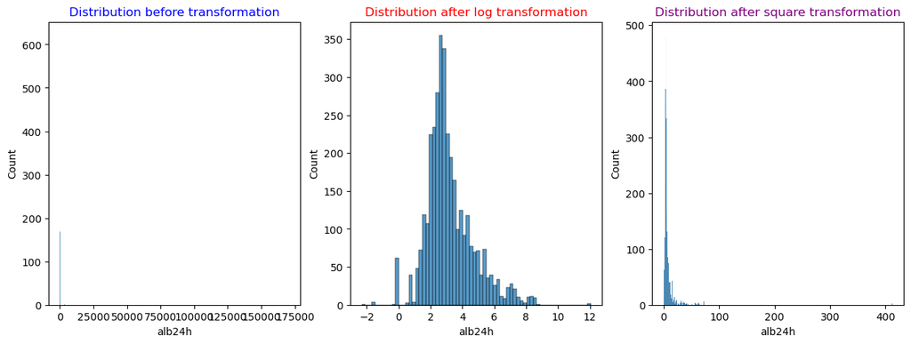

```python
fig, ax = plt.subplots(1,3, figsize = (15,5))
plt.subplots_adjust(hspace=0.5)
transformed_log = df['alb24h'].apply(np.log)
transformed_square = df['alb24h'].apply(np.sqrt)
sns.histplot(data = df, x = df['alb24h'], ax = ax[0])
ax[0].set_title("Distribution before transformation", color='blue')
sns.histplot(data = df, x = transformed_log, ax = ax[1])
ax[1].set_title("Distribution after log transformation", color='red')
sns.histplot(data = df, x = transformed_square, ax = ax[2])
ax[2].set_title("Distribution after square transformation", color='purple')
```

#### ראינו שלוג מנרמל את המשתנה בצורה יותר טובה ולכן ננרמל את המשתנה ע"י לוג

```python
df['alb24h'] = df['alb24h'].apply(np.log)
```

#### בדיקה שאכן המשתנה עבר את הטרנספורמציה והתנרמל

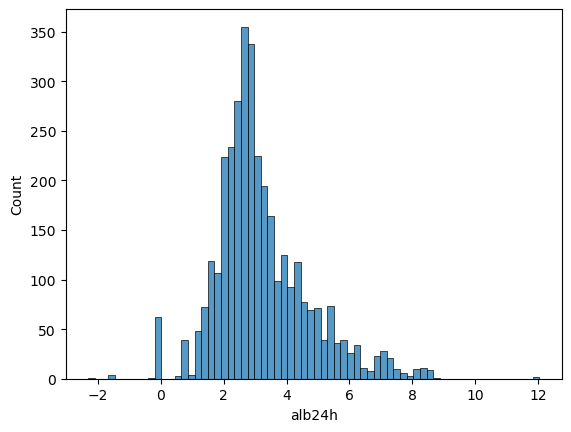

```python
sns.histplot(data = df, x = df['alb24h'])
```

#### יצירת דאטה פריים חדש שמכיל את הנתונים לאחר הטיפול בערכי קיצון

```python
df.to_csv("D:/מבוא למדעי הנתונים/מטלה 1/df_removed_outliers.csv")
```